# Assignment 7: Visualization - Some aspects of ggplot2

*How to do it?*:

- Open the Rmarkdown file of this assignment (link) in Rstudio.
- Right under each **question**, insert a code chunk (you can use the hotkey `Ctrl + Alt + I` to add a code chunk) and code the solution for the question.
- `Knit` the rmarkdown file (hotkey: `Ctrl + Alt + K`) to export an html.
- Publish the html file to your Githiub Page.

*Submission*: Submit the link on Github of the assignment to Blackboard.

**Questions**

Use the data of your own. Produce the following types of plots and comment on each plot. Plots should be meaningful. If you use the data we used in class, make sure the plots are not the same as the ones in the slides. All plots should have title, caption, appropriate labels on x and y-axis.

Data Source: https://www.kaggle.com/gregorut/videogamesales?select=vgsales.csv

```r
library(tidyverse)
library(lubridate)
#I found this video game dataset from kaggle.
df <- read_csv('vgsales.csv')
```

1. Make a plot use `face_wrap` by one categorical variable (`face_wrap(~variable1)`)

```r
#Top 2 Video Game Genres
sort(table(df$Genre),decreasing = TRUE)[1:2]
```

```
##
## Action Sports
##   3316   2346
```

```r
df$Year <- as.numeric(as.character(df$Year))
```

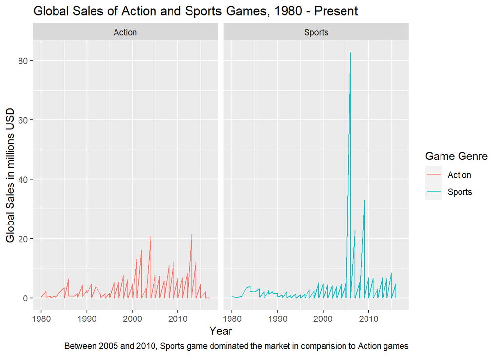

```r
#This timeseries of 1980 to the present day, compares the global sales revenue between the top two video game genres (by number of games published) of Action and Sports.
df %>% filter(Genre=='Action'|Genre=='Sports') %>% ggplot()+
    geom_line(mapping = aes(x = Year, y = Global_Sales, color = Genre))+facet_wrap(~Genre)+
    labs(
        x='Year',
        y = 'Global Sales in millions USD',
        color='Game Genre',
        title = 'Global Sales of Action and Sports Games, 1980 - Present',
        caption = 'Between 2005 and 2010, Sports game dominated the market in comparision to Action games')
```

2. Make a plot use `face_wrap` by two categorical variables (`face_wrap(variable1~variable2)`)

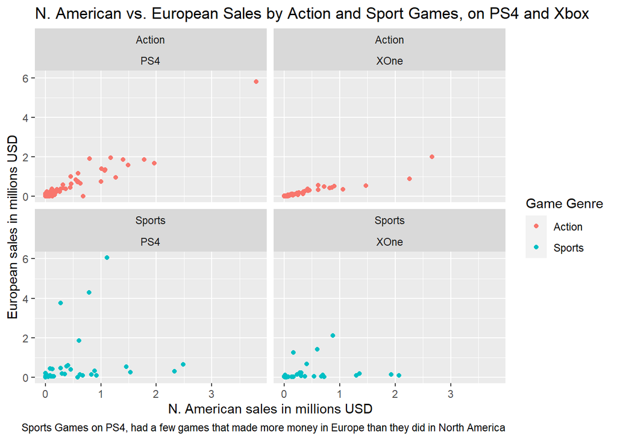

```r
# These scatter graphs shows North American and European sales of the top two genres of Sports and Action by the most popular (and most recent) video game consoles (Xbox One and PS4).
df %>% filter(Platform=='XOne'|Platform=='PS4') %>% filter(Genre=='Action'|Genre=='Sports') %>% ggplot()+
    geom_point(mapping = aes(x = NA_Sales, y = EU_Sales, color = Genre))+facet_wrap(Genre~Platform)+
    labs(
        x='N. American sales in millions USD',
        y = 'European sales in millions USD',
        color='Game Genre',
        title = 'N. American vs. European Sales by Action and Sport Games, on PS4 and Xbox',
        caption = 'Sports Games on PS4, had a few games that made more money in Europe than they did in North America')
```

3. Make a plot use `position ='jitter'`.

```r
#Bottom two Genres from Activision (by number of games published)
df1 = df %>% filter(Publisher=='Activision')
sort(table(df1$Genre),descending=False)[0:2]
```

```
##
## Fighting   Puzzle
##        7        7
```

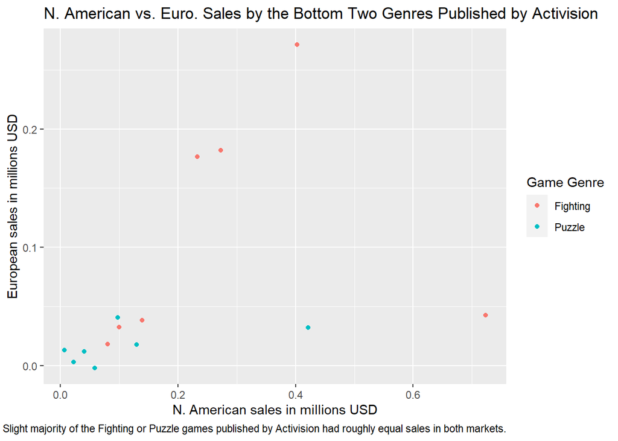

```r
#This Scatter plot shows the European and North American sales of the bottom two genres published by Activison.
#I intenionally used a smaller smaple size for this graph to see more of an impact of jitter.
df %>% filter(Publisher=='Activision') %>% filter(Genre=='Fighting'|Genre=='Puzzle') %>% ggplot()+
    geom_point(mapping = aes(x = NA_Sales, y = EU_Sales, color = Genre),position='jitter')+
    labs(
        x='N. American sales in millions USD',
        y = 'European sales in millions USD',
        color='Game Genre',
        title = 'N. American vs. Euro. Sales by the Bottom Two Genres Published by Activision',
        caption = 'Slight majority of the Fighting or Puzzle games published by Activision had roughly equal sales in both markets.')
```

4. Make a plot use `position ='dodge'`.

```r
#Top 2 Video Game Publishers
sort(table(df$Publisher),decreasing = TRUE)[1:2]
```

```
##
## Electronic Arts      Activision
##            1351             975
```

[figure not shown]

```r
#This bar chart compares the number of games published by the top two video game publishers (by number of games published) and by the top two genres .
df %>% filter(Genre=='Action'|Genre=='Sports') %>% filter(Publisher=='Electronic Arts'|Publisher=='Activision') %>%  ggplot()+ geom_bar(mapping = aes(x = Publisher, fill = Genre),position='dodge')+
labs(
    x='Video Game Publisher',
    y = 'Number of games published',
    color='Game Genre',
    title = 'Activision vs. EA, Number of Action and Sports games published',
    caption = 'EA has almost published as many sports games as Activision has published in both genres combined')
```

[output not shown]

5. Make a plot use `position ='fill'`.

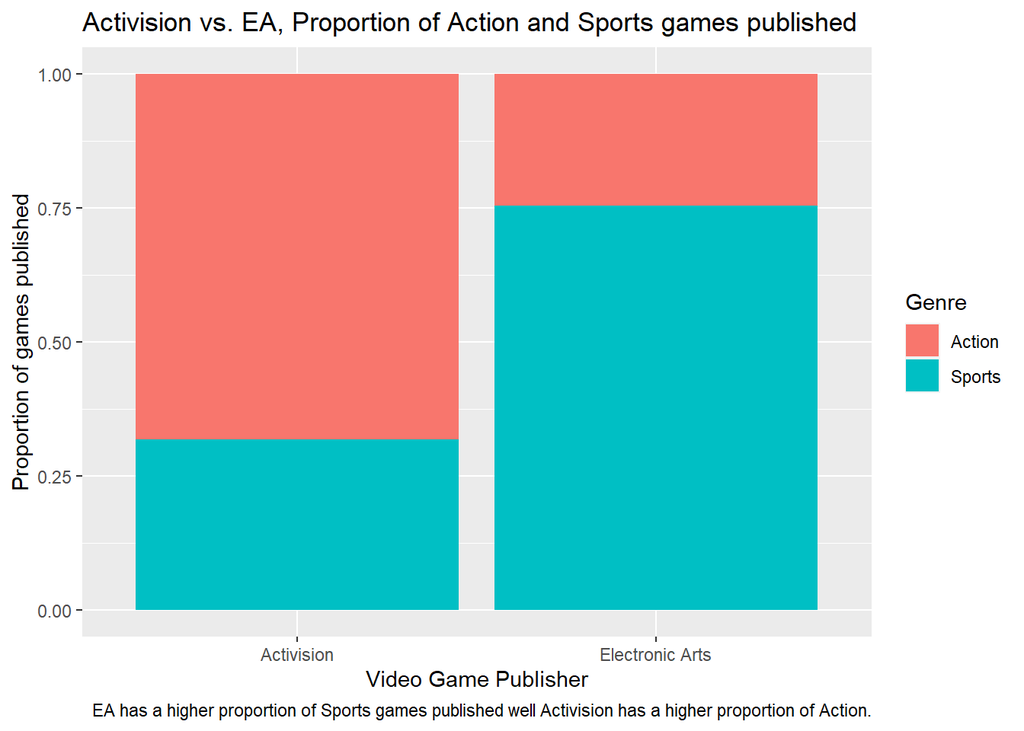

```r
#This bar chart compares the proportion of the top two genres that the top two publishers produce.
df %>% filter(Genre=='Action'|Genre=='Sports') %>% filter(Publisher=='Electronic Arts'|Publisher=='Activision') %>%  ggplot()+ geom_bar(mapping = aes(x = Publisher, fill = Genre),position='fill')+
labs(
    x='Video Game Publisher',
    y = 'Proportion of games published',
    color='Game Genre',
    title = 'Activision vs. EA, Proportion of Action and Sports games published',
    caption = 'EA has a higher proportion of Sports games published well Activision has a higher proportion of Action.')
```

6. Make a plot use `geom_col`.

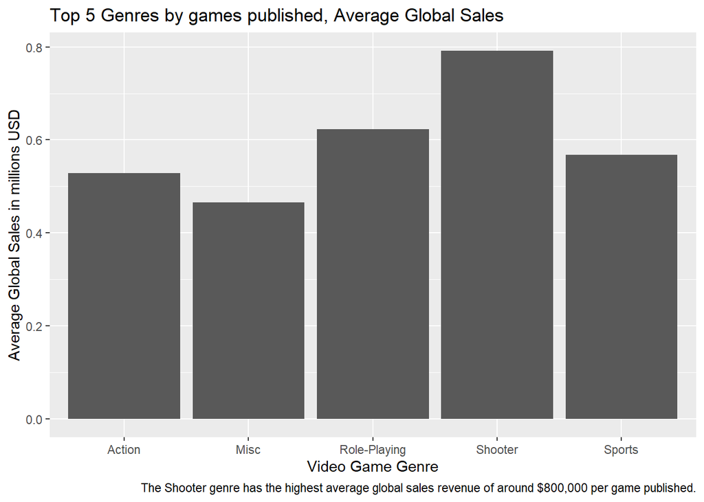

```r
#This column chart shows the top 5 genres (by total games published) and compares their average global sales revenue per game.
df %>% group_by(Genre) %>% filter(Genre == "Action"|Genre == "Sports"|Genre == "Misc"|Genre == "Role-Playing"|Genre == "Shooter") %>% summarise(mean=mean(Global_Sales)) %>%
    ggplot()+
    geom_col(mapping=aes(x=Genre, y=mean))+
labs(
    x='Video Game Genre',
    y = 'Average Global Sales in millions USD',
    title = 'Top 5 Genres by games published, Average Global Sales',
    caption = 'The Shooter genre has the highest average global sales revenue of around $800,000 per game published.')
```

7. Change the theme of one of your plots.

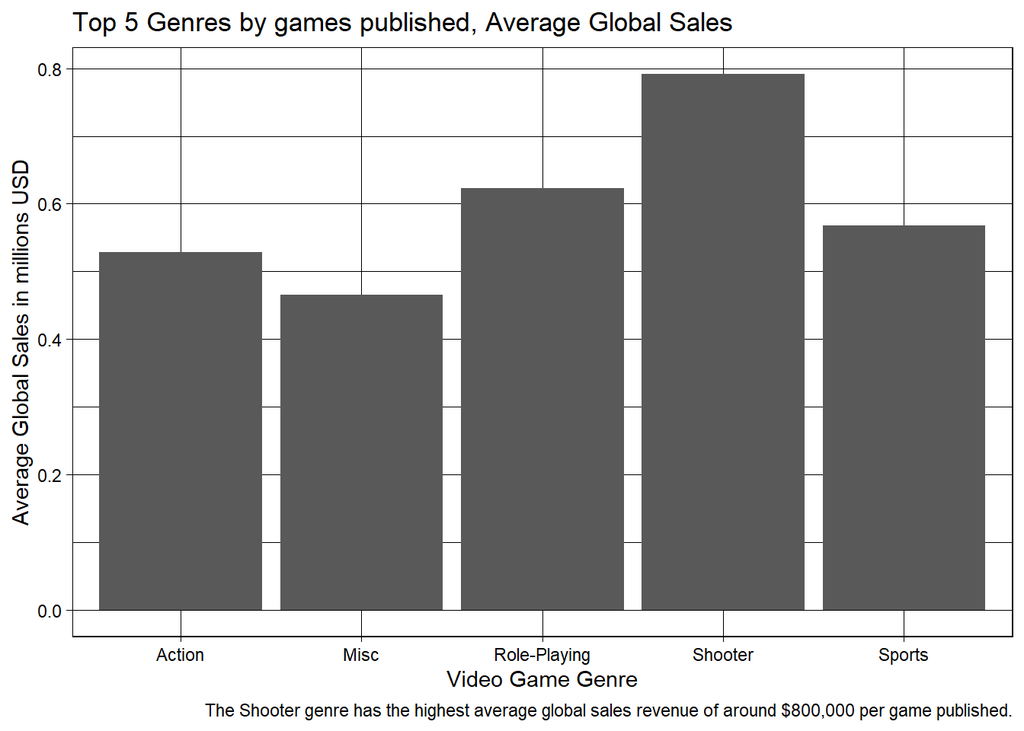

```r
#I changed the theme of Problem 6's graph to highlight the grid and make it easier to see where every genre is at in average global sales per game.
df %>% group_by(Genre) %>% filter(Genre == "Action"|Genre == "Sports"|Genre == "Misc"|Genre == "Role-Playing"|Genre == "Shooter") %>% summarise(mean=mean(Global_Sales)) %>%
    ggplot()+
    geom_col(mapping=aes(x=Genre, y=mean))+
    labs(
        x='Video Game Genre',
        y = 'Average Global Sales in millions USD',
        title = 'Top 5 Genres by games published, Average Global Sales',
        caption = 'The Shooter genre has the highest average global sales revenue of around $800,000 per game published.')+theme_linedraw()
```

8. Save a plot and put a link of the plot to your Github Webpage. To link a plot `abc.png` you just need to insert the following on the README.md

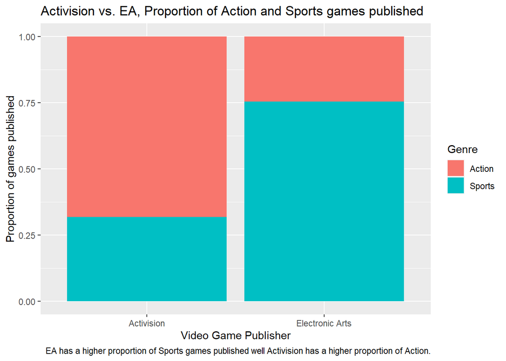

```r
#I will be saving Problem 5's Graph
df %>% filter(Genre=='Action'|Genre=='Sports') %>% filter(Publisher=='Electronic Arts'|Publisher=='Activision') %>%  ggplot()+ geom_bar(mapping = aes(x = Publisher, fill = Genre),position='fill')+
labs(
    x='Video Game Publisher',
    y = 'Proportion of games published',
    color='Game Genre',
    title = 'Activision vs. EA, Proportion of Action and Sports games published',
    caption = 'EA has a higher proportion of Sports games published well Activision has a higher proportion of Action.')+ggsave('abc.png')
```

```r
[Link to the plot](abc.png)
```